# W3cubDocs

/ReactNative

# DatePickerIOS

Use `DatePickerIOS` to render a date/time picker (selector) on iOS. This is a controlled component, so you must hook in to the `onDateChange` callback and update the `date` prop in order for the component to update, otherwise the user's change will be reverted immediately to reflect `props.date` as the source of truth.

### Example

```
import React, { Component } from 'react'
import {
  DatePickerIOS,
  View,
  StyleSheet,
} from 'react-native'

export default class App extends Component {
  constructor(props) {
    super(props);
    this.state = { chosenDate: new Date() };

    this.setDate = this.setDate.bind(this);
  }

  setDate(newDate) {
    this.setState({chosenDate: newDate})
  }

  render() {
    return (
      <View style={styles.container}>
        <DatePickerIOS
          date={this.state.chosenDate}
          onDateChange={this.setDate}
        />
      </View>
    )
  }
}

const styles = StyleSheet.create({
  container: {
    flex: 1,
    justifyContent: 'center'
  },
})
```

[figure not shown]

## Props

- View props...
- `date`
- `onDateChange`
- `maximumDate`
- `minimumDate`
- `minuteInterval`
- `mode`
- `locale`
- `timeZoneOffsetInMinutes`

# Reference

## Props

### `date`

The currently selected date.

| Type | Required |
| --- | --- |
| Date | Yes |

### `onDateChange`

Date change handler.

This is called when the user changes the date or time in the UI. The first and only argument is a Date object representing the new date and time.

| Type | Required |
| --- | --- |
| function | Yes |

### `maximumDate`

Maximum date.

Restricts the range of possible date/time values.

| Type | Required |
| --- | --- |
| Date | No |

Example with `maximumDate` set to December 31, 2017:

[figure not shown]

### `minimumDate`

Minimum date.

Restricts the range of possible date/time values.

| Type | Required |
| --- | --- |
| Date | No |

See `maximumDate` for an example image.

### `minuteInterval`

The interval at which minutes can be selected.

| Type | Required |
| --- | --- |
| enum(1, 2, 3, 4, 5, 6, 10, 12, 15, 20, 30) | No |

Example with `minuteInterval` set to `10`:

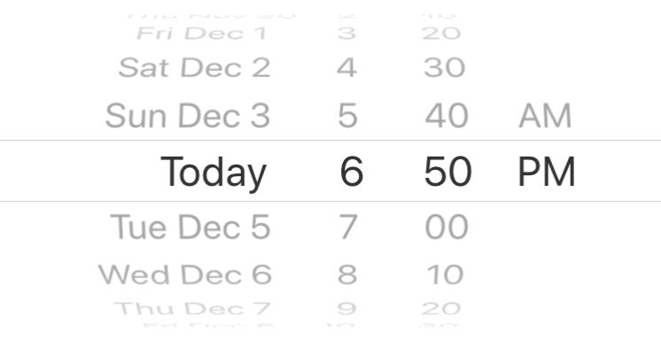

### `mode`

The date picker mode.

| Type | Required |
| --- | --- |
| enum('date', 'time', 'datetime') | No |

Example with `mode` set to `date`, `time`, and `datetime`:

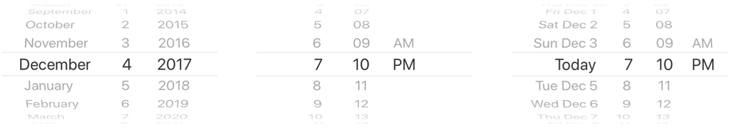

### `locale`

The locale for the date picker. Value needs to be a [Locale ID](https://developer.apple.com/library/content/documentation/MacOSX/Conceptual/BPInternational/LanguageandLocaleIDs/LanguageandLocaleIDs.html).

| Type | Required |
| --- | --- |
| String | No |

### `timeZoneOffsetInMinutes`

Timezone offset in minutes.

By default, the date picker will use the device's timezone. With this parameter, it is possible to force a certain timezone offset. For instance, to show times in Pacific Standard Time, pass -7 * 60.

| Type | Required |
| --- | --- |
| number | No |

© 2015–2018 Facebook Inc.  
Licensed under the Creative Commons Attribution 4.0 International Public License.  
https://facebook.github.io/react-native/docs/datepickerios.html